# Analysis of new example

James Yu, 16 February 2022

```python
import matplotlib.pyplot as plt
import numpy as np

# some convenient labels
INFLUENTIAL = 1
FOLLOWER = 2
STUBBORN = 3
```

```python
def get_payoff(A, B, R, x_0, T, delta):
    Q = (1/x_0.size) * np.identity(x_0.size)
    K_t = Q
    K_sequence = [Q]
    for i in range(T):
        K_t = delta * A.T @ (K_t - K_t @ B @ np.linalg.inv(B.T @ K_t @ B + R / delta) @ B.T @ K_t) @ A + Q
        K_sequence.insert(0, K_t)

    x_t = x_0
    r_ts = []
    payoff = 0
    payoffs = []
    x_ts = [x_0]
    i = 0
    for K in K_sequence[1:]:
        L = -(np.linalg.inv(B.T @ K @ B + R / delta) @ B.T @ K @ A)
        r_t = L @ x_t
        r_ts.append(r_t.item())
        payoff += (-1 * delta**i * (x_t.T @ Q @ x_t)).item() + (-1 * delta**i * (R * r_t**2)).item()
        payoffs.append(payoff)
        x_t_new = A @ x_t + B @ r_t
        x_ts.append(x_t_new)
        x_t = x_t_new
        i += 1

    return payoff, payoffs, r_ts, K_sequence, x_ts
```

```python
from io import BytesIO
from PIL import Image
from IPython.display import HTML
from base64 import b64encode

def solve(target, delta = 1, x_0 = np.array([[-10], [7], [20]], ndmin = 2)):
    T = 30
    R = 0
    b = 0.1 # the influence weight
    A = np.array([
      [a * [1.0, 1.0-b][target == INFLUENTIAL] for a in A_nobody[0]], # influential agent
      [a * [1.0, 1.0-b][target == FOLLOWER] for a in A_nobody[1]], # follower agent
      [a * [1.0, 1.0-b][target == STUBBORN] for a in A_nobody[2]], # stubborn agent
    ], ndmin = 2)
    B = np.array([
      [[0.0, b][target == INFLUENTIAL]],
      [[0.0, b][target == FOLLOWER]],
      [[0.0, b][target == STUBBORN]],
    ], ndmin = 2)
    return get_payoff(A, B, R, x_0, T, delta)
```

## Test with $\delta = 0.8$

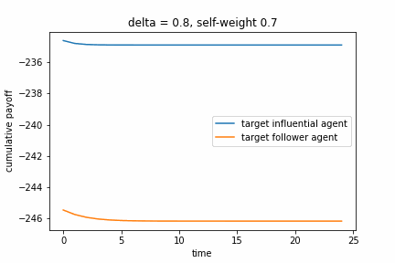

```python
images = []
for aii in np.linspace(0.7, 0.999, 30):
    A_nobody = [
        [0.8, 0.2, 0.0],
        [0.5, 0.5, 0.0],
        [1 - aii, 0.0, aii]
    ]
    for agent in ["INFLUENTIAL", "FOLLOWER"]:
        payoff, payoffs, _, _, _ = solve(globals()[agent], delta = 0.8)
        plt.plot(range(25), payoffs[5:], label = "target " + agent.lower() + " agent")
    plt.legend()
    plt.xlabel("time")
    plt.ylabel("cumulative payoff")
    plt.title("delta = 0.8, self-weight " + str(aii))
    filex = BytesIO()
    plt.savefig(filex, format = "png", facecolor= (1, 1, 1))
    plt.clf()
    plt.close()
    filex.seek(0)
    images.append(filex)

# graphical engine reused from
# https://github.com/jbrightuniverse/Generalized-Price-of-Anarchy/blob/main/Generalized%20Price%20of%20Anarchy.ipynb
imgs = [Image.open(image) for image in images]

masterfilex = BytesIO()
imgs[0].save(fp=masterfilex, format='GIF', append_images=imgs[1:], save_all=True, duration=200, loop=0)
HTML("<img src='data:…'/>".format(b64encode(masterfilex.getvalue()).decode('utf-8')))
```

No crossovers happen in this scenario.

## Using $\delta = 0.9$

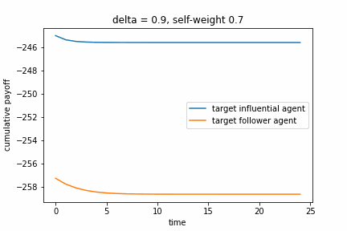

```python
images = []
for aii in np.linspace(0.7, 0.999, 30):
    A_nobody = [
        [0.8, 0.2, 0.0],
        [0.5, 0.5, 0.0],
        [1 - aii, 0.0, aii]
    ]
    for agent in ["INFLUENTIAL", "FOLLOWER"]:
        payoff, payoffs, _, _, _ = solve(globals()[agent], delta = 0.9)
        plt.plot(range(25), payoffs[5:], label = "target " + agent.lower() + " agent")
    plt.legend()
    plt.xlabel("time")
    plt.ylabel("cumulative payoff")
    plt.title("delta = 0.9, self-weight " + str(aii))
    filex = BytesIO()
    plt.savefig(filex, format = "png", facecolor= (1, 1, 1))
    plt.clf()
    plt.close()
    filex.seek(0)
    images.append(filex)

# graphical engine reused from
# https://github.com/jbrightuniverse/Generalized-Price-of-Anarchy/blob/main/Generalized%20Price%20of%20Anarchy.ipynb
imgs = [Image.open(image) for image in images]

masterfilex = BytesIO()
imgs[0].save(fp=masterfilex, format='GIF', append_images=imgs[1:], save_all=True, duration=200, loop=0)
HTML("<img src='data:…'/>".format(b64encode(masterfilex.getvalue()).decode('utf-8')))
```

Here a crossover occurs. An example:

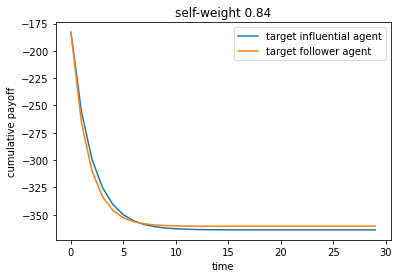

```python
aii = 0.84
A_nobody = [
    [0.8, 0.2, 0.0],
    [0.5, 0.5, 0.0],
    [1 - aii, 0.0, aii]
]
for agent in ["INFLUENTIAL", "FOLLOWER"]:
    payoff, payoffs, _, _, _ = solve(globals()[agent], delta = 0.9)
    plt.plot(range(30), payoffs, label = "target " + agent.lower() + " agent")
plt.legend()
plt.xlabel("time")
plt.ylabel("cumulative payoff")
plt.title("self-weight " + str(aii))
plt.show()
```

```python
_, _, r_set, K_set, xt_set = solve(INFLUENTIAL, delta = 0.9)
```

```python
_, _, r_set_2, K_set_2, xt_set_2 = solve(FOLLOWER, delta = 0.9)
```

### Data for targeting influential agent:

```python
print(r_set) # the messages
```

```
[30.475305433680788, 2.101957402072313, 2.7616348869145897, 2.659164980653604, 2.325949621344493, 1.9570402245358993, 1.6184908961606457, 1.3278722250839623, 1.0853527773252982, 0.8855492124835114, 0.7219219089601014, 0.5883034505183966, 0.47934272483736806, 0.3905540901958695, 0.318235502856973, 0.…
```

```python
print("\n".join([",".join(str(round(a[0], 2)) for a in i) for i in xt_set])) # the opinion evolution
```

```
-10,7,20
-2.89,-1.5,15.2
-2.14,-2.2,12.31
-1.66,-2.17,9.99
-1.32,-1.92,8.13
-1.06,-1.62,6.62
-0.86,-1.34,5.39
-0.7,-1.1,4.39
-0.57,-0.9,3.57
-0.46,-0.73,2.91
-0.38,-0.6,2.37
-0.31,-0.49,1.93
-0.25,-0.4,1.57
-0.2,-0.32,1.28
-0.17,-0.26,1.04
-0.14,-0.21,0.85
-0.11,-0.18,0.69
-0.09,-0.14,0.56
-0.07,-0.12,0.46
-0.06,-0.09,0.37
-0.05,-0.08,0.31
-0.04,-0.06,0.25
-0.03,-0.05,0.2
-0.03,-0.04,0.17
-0.02,-0.03,0.13
-0.02,-0.03,0.11
-0.01,-0.02,0.09
-0.01,-0.02,0.07
-0.01,-0.01,0.06
-0.0,-0.01,0.05
0.0,-0.01,0.04
```

Payoffs:

```python
my_payoff = 0
my_payoff_main = 0
for x_t in xt_set:
    my_payoff += x_t[0]**2 * (1/3) + x_t[1]**2 * (1/3)
    my_payoff_main += x_t[0]**2 * (1/3) + x_t[1]**2 * (1/3) + x_t[2]**2 * (1/3)

print(-my_payoff.item(), "without agent 3; vs with agent 3:", -my_payoff_main.item())
```

```
-64.4257207967792 without agent 3; vs with agent 3: -423.90306671152456
```

### Data for targeting follower agent:

```python
print(r_set_2) # messages
```

```
[21.795555526040133, 32.46143169602968, 25.174308011031314, 19.51687723443006, 15.125956734169522, 11.71903288877912, 9.076399231582688, 7.027237818881661, 5.43877579407882, 4.207839674511992, 3.2542787219733804, 2.5158449819379007, 1.94420831630819, 1.5018555824769944, 1.159678384404323, 0.89509694…
```

```python
print("\n".join([",".join(str(round(a[0], 2)) for a in i) for i in xt_set_2])) # opinion evolution
```

```
-10,7,20
-6.6,0.83,15.2
-5.11,0.65,11.71
-3.96,0.51,9.02
-3.07,0.4,6.94
-2.37,0.31,5.34
-1.84,0.24,4.11
-1.42,0.19,3.16
-1.1,0.15,2.42
-0.85,0.12,1.86
-0.66,0.09,1.43
-0.51,0.07,1.09
-0.39,0.06,0.84
-0.3,0.04,0.64
-0.23,0.03,0.49
-0.18,0.03,0.37
-0.14,0.02,0.29
-0.11,0.02,0.22
-0.08,0.01,0.17
-0.06,0.01,0.13
-0.05,0.01,0.1
-0.04,0.01,0.07
-0.03,0.0,0.06
-0.02,0.0,0.04
-0.02,0.0,0.03
-0.01,0.0,0.02
-0.01,0.0,0.02
-0.01,0.0,0.01
-0.01,0.0,0.01
-0.0,0.0,0.01
-0.0,0.0,0.01
```

Payoffs:

```python
my_payoff2 = 0
my_payoff2_main = 0
for x_t in xt_set_2:
    my_payoff2 += x_t[0]**2 * (1/3) + x_t[1]**2 * (1/3)
    my_payoff2_main += x_t[0]**2 * (1/3) + x_t[1]**2 * (1/3) + x_t[2]**2 * (1/3)

print(-my_payoff2.item(), "without agent 3; vs with agent 3:", -my_payoff2_main.item())
```

```
-86.53914734685634 without agent 3; vs with agent 3: -408.995675163008
```

From this, it would appear that the crossover in the payoff plot occurs due to the weight of the stubborn agent's opinions being much heavier when targeting the influential agent, even though the weight of the other two agents is lesser when targeting the influential agent.

```python
print([round(x_t[2].item(), 2) for x_t in xt_set]) # first case
```

```
[20, 15.2, 12.31, 9.99, 8.13, 6.62, 5.39, 4.39, 3.57, 2.91, 2.37, 1.93, 1.57, 1.28, 1.04, 0.85, 0.69, 0.56, 0.46, 0.37, 0.31, 0.25, 0.2, 0.17, 0.13, 0.11, 0.09, 0.07, 0.06, 0.05, 0.04]
```

```python
print([round(x_t[2].item(), 2) for x_t in xt_set_2]) # second case
```

```
[20, 15.2, 11.71, 9.02, 6.94, 5.34, 4.11, 3.16, 2.42, 1.86, 1.43, 1.09, 0.84, 0.64, 0.49, 0.37, 0.29, 0.22, 0.17, 0.13, 0.1, 0.07, 0.06, 0.04, 0.03, 0.02, 0.02, 0.01, 0.01, 0.01, 0.01]
```

This also explains why $\delta = 0.8$ removes this effect: the smaller $\delta$ is, the less future periods have an effect on the payoff, and so the sustained opinions in the first case are less important.

```python
A = np.array([
    [0.8 * 0.9, 0.2 * 0.9, 0.0],
    [0.5, 0.5, 0.0],
    [0.16, 0.0, 0.84]
], ndmin = 2)
A
```

```
array([[0.72, 0.18, 0.  ],
       [0.5 , 0.5 , 0.  ],
       [0.16, 0.  , 0.84]])
```

```python
A = np.array([
    [0.8, 0.2, 0.0],
    [0.5 * 0.9, 0.5 * 0.9, 0.0],
    [0.16, 0.0, 0.84]
], ndmin = 2)
A
```

```
array([[0.8 , 0.2 , 0.  ],
       [0.45, 0.45, 0.  ],
       [0.16, 0.  , 0.84]])
```

Agent 3 evolution in first period:

```python
x_1_agent3 = 0.84 * 20 + 0.16 * -10
x_1_agent3
```

```
15.200000000000001
```

Second period if targeting follower:

```python
0.84 * x_1_agent3 + 0.16 * -6.6
```

```
11.712
```

Second period if targeting influential agent:

```python
0.84 * x_1_agent3 + 0.16 * -2.89
```

```
12.3056
```

From here we can see the reason for the slower convergence of agent 3 in the influential case: the magnitude of the opinion of agent 1 is greater when targeting the follower agent because it is more extreme to begin with. Since it converges slower, it stays more negative for longer, and thus allows agent 3 to converge faster.

K matrices for first case (target agent 1):

```python
K_set.reverse()
K_set
```

```
[array([[0.33333333, 0.        , 0.        ],
        [0.        , 0.33333333, 0.        ],
        [0.        , 0.        , 0.33333333]]),
 array([[0.41601333, 0.075     , 0.04032   ],
        [0.075     , 0.40833333, 0.        ],
        [0.04032   , 0.        , 0.54501333]]),
 array([[ 0.4335864 ,  0.08830936,  0.06270444],
        [ 0.08830936,  0.42216606, -0.00274768],
        [ 0.06270444, -0.00274768,  0.67695698]]),
 array([[ 0.43742727,  0.08982313,  0.07492172],
        [ 0.08982313,  0.42427382, -0.00586611],
        [ 0.07492172, -0.00586611,  0.75746943]]),
 array([[ 0.43874121,  0.0897815 ,  0.08203847],
        [ 0.0897815 ,  0.4246449 , -0.00803282],
        [ 0.08203847, -0.00803282,  0.8062076 ]]),
 array([[ 0.43939206,  0.08962423,  0.08628111],
        [ 0.08962423,  0.42474465, -0.00938223],
        [ 0.08628111, -0.00938223,  0.83556586]]),
 array([[ 0.43976345,  0.08951168,  0.08882176],
        [ 0.08951168,  0.42478767, -0.01019892],
        [ 0.08882176, -0.01019892,  0.85319187]]),
 array([[ 0.43998329,  0.08944177,  0.09034294],
        [ 0.08944177,  0.42481113, -0.01068914],
        [ 0.09034294, -0.01068914,  0.86375176]]),
 array([[ 0.44011446,  0.08939961,  0.09125298],
        [ 0.08939961,  0.42482486, -0.01098259],
        [ 0.09125298, -0.01098259,  0.87007003]]),
 array([[ 0.44019283,  0.08937435,  0.09179703],
        [ 0.08937435,  0.42483302, -0.01115804],
        [ 0.09179703, -0.01115804,  0.87384745]]),
 array([[ 0.44023966,  0.08935925,  0.09212214],
        [ 0.08935925,  0.4248379 , -0.01126289],
        [ 0.09212214, -0.01126289,  0.87610473]]),
 array([[ 0.44026763,  0.08935023,  0.09231636],
        [ 0.08935023,  0.42484081, -0.01132553],
        [ 0.09231636, -0.01132553,  0.87745323]]),
 array([[ 0.44028434,  0.08934484,  0.09243236],
        [ 0.08934484,  0.42484254, -0.01136294],
        [ 0.09243236, -0.01136294,  0.87825869]]),
 array([[ 0.44029432,  0.08934162,  0.09250165],
```

[output cut: 38 more lines]

```
 array([[ 0.44030909,  0.08933686,  0.09260424],
        [ 0.08933686,  0.42484512, -0.01141837],
        [ 0.09260424, -0.01141837,  0.87945205]]),
 array([[ 0.4403091 ,  0.08933685,  0.09260429],
        [ 0.08933685,  0.42484512, -0.01141839],
        [ 0.09260429, -0.01141839,  0.8794524 ]]),
 array([[ 0.4403091 ,  0.08933685,  0.09260432],
        [ 0.08933685,  0.42484512, -0.0114184 ],
        [ 0.09260432, -0.0114184 ,  0.87945261]]),
 array([[ 0.44030911,  0.08933685,  0.09260434],
        [ 0.08933685,  0.42484512, -0.01141841],
        [ 0.09260434, -0.01141841,  0.87945274]]),
 array([[ 0.44030911,  0.08933685,  0.09260435],
        [ 0.08933685,  0.42484512, -0.01141841],
        [ 0.09260435, -0.01141841,  0.87945281]])]
```

Target agent 2:

```python
K_set_2.reverse()
K_set_2
```

```
[array([[0.33333333, 0.        , 0.        ],
        [0.        , 0.33333333, 0.        ],
        [0.        , 0.        , 0.33333333]]),
 array([[0.53301333, 0.048     , 0.04032   ],
        [0.048     , 0.34533333, 0.        ],
        [0.04032   , 0.        , 0.54501333]]),
 array([[0.65835288, 0.07695439, 0.09031035],
        [0.07695439, 0.35228163, 0.00609638],
        [0.09031035, 0.00609638, 0.6794386 ]]),
 array([[0.73901434, 0.09494471, 0.1359864 ],
        [0.09494471, 0.35642886, 0.01345357],
        [0.1359864 , 0.01345357, 0.76473703]]),
 array([[0.7925513 , 0.10658934, 0.1725183 ],
        [0.10658934, 0.35902737, 0.02001928],
        [0.1725183 , 0.02001928, 0.81864945]]),
 array([[0.8288304 , 0.11436792, 0.19963332],
        [0.11436792, 0.36072597, 0.02518613],
        [0.19963332, 0.02518613, 0.85249961]]),
 array([[0.85361052, 0.11964956, 0.2188144 ],
        [0.11964956, 0.36186586, 0.02897719],
        [0.2188144 , 0.02897719, 0.87358796]]),
 array([[0.8705068 , 0.12324895, 0.23193276],
        [0.12324895, 0.36263909, 0.03163606],
        [0.23193276, 0.03163606, 0.88662308]]),
 array([[0.88194189, 0.12569108, 0.24068219],
        [0.12569108, 0.3631636 , 0.03344252],
        [0.24068219, 0.03344252, 0.89462182]]),
 array([[0.88960241, 0.12733368, 0.24640529],
        [0.12733368, 0.36351718, 0.03464109],
        [0.24640529, 0.03464109, 0.8994983 ]]),
 array([[0.89467759, 0.12842696, 0.25009119],
        [0.12842696, 0.36375332, 0.03542179],
        [0.25009119, 0.03542179, 0.9024544 ]]),
 array([[0.89800304, 0.12914671, 0.25243515],
        [0.12914671, 0.3639094 , 0.03592288],
        [0.25243515, 0.03592288, 0.90423752]]),
 array([[0.9001593 , 0.12961553, 0.25391009],
        [0.12961553, 0.36401147, 0.03624061],
        [0.25391009, 0.03624061, 0.90530842]]),
 array([[0.9015439 , 0.12991788, 0.25482992],
```

[output cut: 38 more lines]

```
 array([[0.90388808, 0.13043452, 0.2562874 ],
        [0.13043452, 0.36419149, 0.03675987],
        [0.2562874 , 0.03675987, 0.90688493]]),
 array([[0.90388952, 0.13043485, 0.25628813],
        [0.13043485, 0.36419157, 0.03676003],
        [0.25628813, 0.03676003, 0.9068853 ]]),
 array([[0.90389038, 0.13043504, 0.25628856],
        [0.13043504, 0.36419161, 0.03676013],
        [0.25628856, 0.03676013, 0.90688552]]),
 array([[0.90389089, 0.13043516, 0.25628881],
        [0.13043516, 0.36419164, 0.03676019],
        [0.25628881, 0.03676019, 0.90688564]]),
 array([[0.90389119, 0.13043523, 0.25628896],
        [0.13043523, 0.36419165, 0.03676022],
        [0.25628896, 0.03676022, 0.90688571]])]
```